# Movie Revenue

```r
library(tidyverse)
library(caret)
library(Amelia)
library(stringr)
library(DataExplorer)
library(fastDummies)
library(forcats)
library(purrr)
library(lubridate)
library(scales)
library(patchwork)
library(ggthemes)
```

# 1 Exploratory Data Analysis

```r
movie_train <- read.csv("train.csv", stringsAsFactors = FALSE, na.strings = c("", NA))
movie_test <- read.csv("test.csv", stringsAsFactors = FALSE, na.strings = c("", NA))
movie_data <- bind_rows(movie_train, movie_test)

colnames(movie_data)[1] <- "id"
colnames(movie_train)[1] <- "id"
colnames(movie_test)[1] <- "id"

glimpse(movie_data)
```

```
## Rows: 7,398
## Columns: 23
## $ id                    <int> 1, 2, 3, 4, 5, 6, 7, 8, 9, 10, 11, 12, 13, 14, …
## $ belongs_to_collection <chr> "[{'id': 313576, 'name': 'Hot Tub Time Machine …
## $ budget                <int> 14000000, 40000000, 3300000, 1200000, 0, 800000…
## $ genres                <chr> "[{'id': 35, 'name': 'Comedy'}]", "[{'id': 35, …
## $ homepage              <chr> NA, NA, "http://sonyclassics.com/whiplash/", "h…
## $ imdb_id               <chr> "tt2637294", "tt0368933", "tt2582802", "tt18214…
## $ original_language     <chr> "en", "en", "en", "hi", "ko", "en", "en", "en",…
## $ original_title        <chr> "Hot Tub Time Machine 2", "The Princess Diaries…
## $ overview              <chr> "When Lou, who has become the \"father of the I…
## $ popularity            <dbl> 6.575393, 8.248895, 64.299990, 3.174936, 1.1480…
## $ poster_path           <chr> "/tQtWuwvMf0hCc2QR2tkolwl7c3c.jpg", "/w9Z7A0GHE…
## $ production_companies  <chr> "[{'name': 'Paramount Pictures', 'id': 4}, {'na…
## $ production_countries  <chr> "[{'iso_3166_1': 'US', 'name': 'United States o…
## $ release_date          <chr> "2/20/15", "8/6/04", "10/10/14", "3/9/12", "2/5…
## $ runtime               <int> 93, 113, 105, 122, 118, 83, 92, 84, 100, 91, 11…
## $ spoken_languages      <chr> "[{'iso_639_1': 'en', 'name': 'English'}]", "[{…
## $ status                <chr> "Released", "Released", "Released", "Released",…
## $ tagline               <chr> "The Laws of Space and Time are About to be Vio…
## $ title                 <chr> "Hot Tub Time Machine 2", "The Princess Diaries…
## $ Keywords              <chr> "[{'id': 4379, 'name': 'time travel'}, {'id': 9…
## $ cast                  <chr> "[{'cast_id': 4, 'character': 'Lou', 'credit_id…
## $ crew                  <chr> "[{'credit_id': '59ac067c92514107af02c8c8', 'de…
## $ revenue               <int> 12314651, 95149435, 13092000, 16000000, 3923970…
```

## 1.1 Exploratory Plots

When looking at the plot that shows the proportion of missing values for each variable in the dataset. There appears to be a lot of missing values in a few of the variables and then a number of the variables have only a few missing values. Although it shows that there are a lot of missing values for revenue, that isn’t a problem because those are missing values from the test set since the revenue is not included in the test set. For dealing with the missing values, it is easier to combine the training and test set and then to split them apart again after deciding what to do with the missing values.

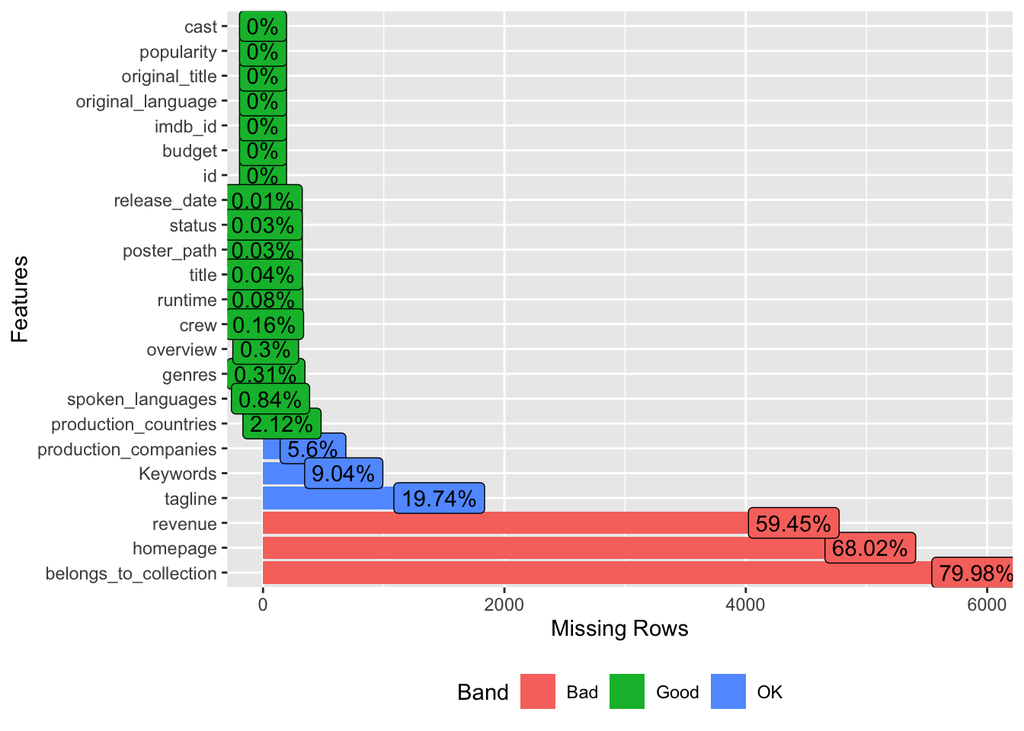

```r
# Plot of how many values are missing
plot_missing(movie_data)
```

There are only a few numeric variables, so the relationship between those variables and revenue are explored in the scatterplots below.

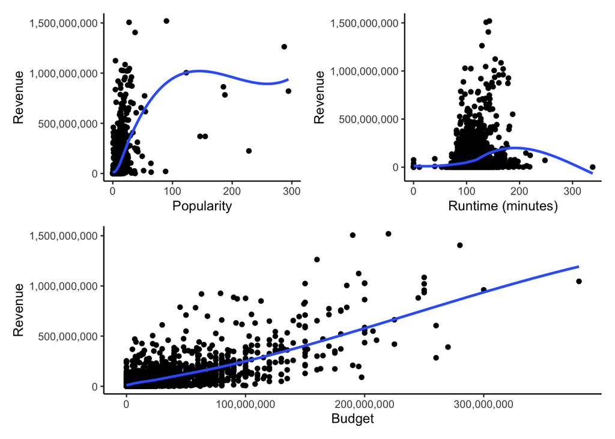

```r
# Plots of numeric variables
p1 <- ggplot(movie_data, aes(x = popularity, y = revenue)) +
  geom_point() +
  geom_smooth(method = "loess", se = FALSE) +
  xlim(0, 300) +
  labs(x = "Popularity", y = "Revenue") +
  scale_y_continuous(labels = comma) +
  theme_classic()
p2 <- ggplot(movie_data, aes(x = runtime, y = revenue)) +
  geom_point() +
  geom_smooth(method = "loess", se = FALSE) +
  labs(x = "Runtime (minutes)", y = "Revenue") +
  scale_y_continuous(labels = comma) +
  theme_classic()

p3 <- ggplot(movie_data, aes(x = budget, y = revenue)) +
  geom_point() +
  geom_smooth(method = "loess", se = FALSE) +
  labs(x = "Budget", y = "Revenue") +
  scale_y_continuous(labels = comma) +
  scale_x_continuous(labels = comma) +
  theme_classic()

(p1 + p2)/p3
```

# 2 Data Cleaning

## 2.1 Response Variable

When dealing with revenue, something that is in the millions of dollars, there are likely to be outliers and the distribution of revenue is likely to be skewed. From the plot below, the distribution of revenue is highly right skewed. When fitting a model, it will likely be better to use the log of revenue. The distribution of the log of revenue is less skewed and it can help so the outliers don’t influence the model when training the model.

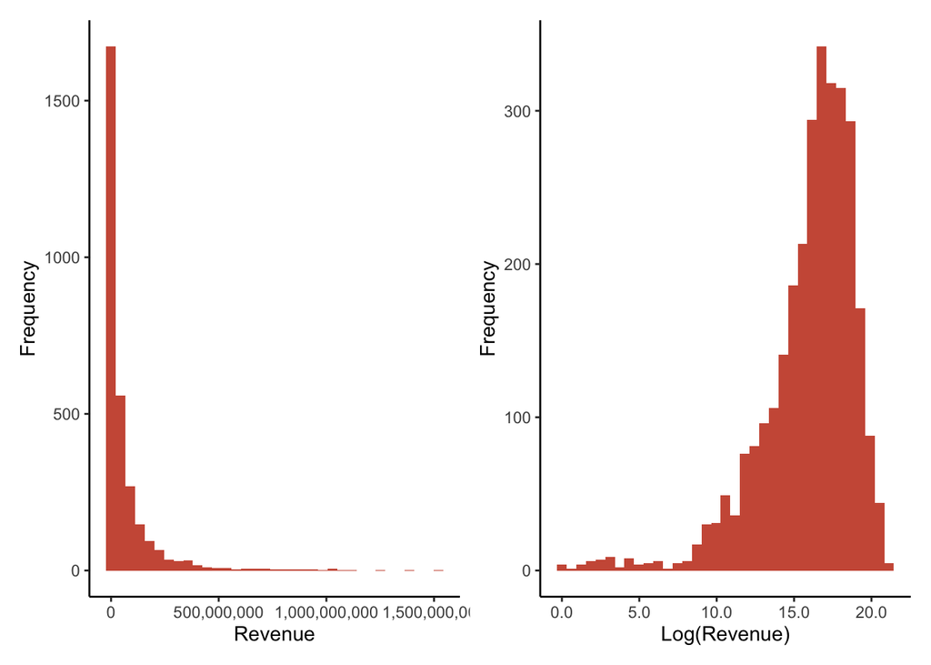

```r
p1a <- ggplot(movie_data, aes(x = revenue)) +
  geom_histogram(fill = "coral3", bins = 35) +
  scale_x_continuous(labels = comma) +
  labs(x = "Revenue", y = "Frequency") +
  theme_classic()
p1b <- ggplot(movie_data %>% filter(!is.na(revenue)), aes(x = log(revenue))) +
  geom_histogram(fill = "coral3", bins = 35) +
  scale_x_continuous(labels = comma) +
  labs(x = "Log(Revenue)", y = "Frequency") +
  theme_classic()
p1a + p1b
```

## 2.2 Initial Variable Dropping

With most of the categorical variables, there is data manipulation and cleaning that needs to be done to extract the useful information. Most of the important variables are in JSON format and the relevant information will be extracted using regular expressions mostly.

There are some variables, `imdb_id`, `original_title`, `overview`, `poster_path`, and `status` that don’t provide a lot of information about the revenue a movie brings in. As a result, those variables are dropped from the dataset. There is also one movie that did not have a release date listed, so I looked up the release data for the movie. After adding that release date, the release date was changed from a character to a date variable.

```r
movie_data <- movie_data %>% select(-imdb_id, -original_title, -overview, -poster_path, -status)

# Insert the release data for the one missing value
movie_data[is.na(movie_data$release_date),]$release_date <- "05/01/00"
# Change release date to a date
movie_data$release_date <- parse_date_time2(movie_data$release_date, orders = "%m%d%y", cutoff_2000 = 20L)
```

## 2.3 Categorical variables

Next, I want to look at the variables that have a high percentage of missing values. The variables `belongs_to_collection` and `homepage` are missing more than 50% of the time. `Keywords` and `tagline` are the other variables that have quite a few missing values. The revenue variable is not of concern to me here since the missing values for revenue come from the test set. Since there are so many missing values for these variables, I created dummy variables to indicate whether or not an observation had keywords, a tagline, a homepage, or belonged to a collection. The boxplots below show movies that have keywords, a tagline, a homepage, or belong to collection have a higher revenue on average. Even though the difference is small for `homepage`, I will drop the actual variables and use the dummy variables for all four of the variables. Also, the log of revenue is used to better show the difference between the group and to limit the influence outliers have on the plots.

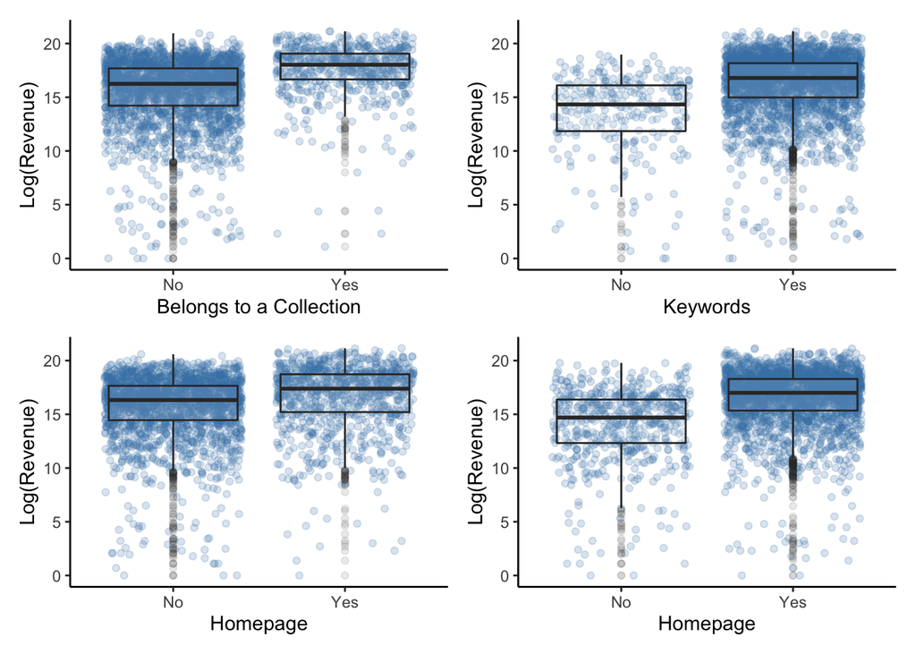

```r
# Analyzing features with many NAs

movie_nas <- movie_train %>%
  select(Keywords, tagline, homepage, belongs_to_collection, revenue) %>%
  mutate_at(.funs = list(cat = ~ifelse(is.na(.), 0, 1)),
            .vars = c("Keywords", "tagline", "homepage",
                      "belongs_to_collection"))

p4 <- ggplot(movie_nas, aes(x = factor(belongs_to_collection_cat), y = log(revenue))) +
  geom_jitter(alpha = .2, color = 'steelblue') +
  geom_boxplot(alpha = .1) +
  scale_x_discrete(labels = c("No", "Yes")) +
  labs(x = 'Belongs to a Collection', y = 'Log(Revenue)') +
  theme_classic()

p5 <- ggplot(movie_nas, aes(x = factor(Keywords_cat), y = log(revenue))) +
  geom_jitter(alpha = .2, color = 'steelblue') +
  geom_boxplot(alpha = .1) +
  scale_x_discrete(labels = c("No", "Yes")) +
  labs(x = 'Keywords', y = 'Log(Revenue)') +
  theme_classic()

p6 <- ggplot(movie_nas, aes(x = factor(homepage_cat), y = log(revenue))) +
  geom_jitter(alpha = .2, color = 'steelblue') +
  geom_boxplot(alpha = .1) +
  scale_x_discrete(labels = c("No", "Yes")) +
  labs(x = 'Homepage', y = 'Log(Revenue)') +
  theme_classic()

p7 <- ggplot(movie_nas, aes(x = factor(tagline_cat), y = log(revenue))) +
  geom_jitter(alpha = .2, color = 'steelblue') +
  geom_boxplot(alpha = .1) +
  scale_x_discrete(labels = c("No", "Yes")) +
  labs(x = 'Homepage', y = 'Log(Revenue)') +
  theme_classic()

p4 + p5 + p6 + p7
```

```r
# Add indicator columns to main data
movie_data <- movie_data %>%
  mutate_at(.funs = list(ind = ~ifelse(is.na(.), 0, 1)),
            .vars = c("Keywords", "tagline", "homepage",
                      "belongs_to_collection"))

# Drop columns
movie_data <- movie_data %>%
  select(-belongs_to_collection, -homepage, -tagline, -Keywords)
```

## 2.4 Cast and Crew (counts for each)

There were a number of ideas of how to work with the cast and crew. There is a possibility of pulling out the most commonly known actors and directors to see if those movies generally had a higher revenue. I also thought about counting the number of high profile stars in each movie and seeing if that has an influence on the revenue. In the end, I simply decided to count the number of crew members and the number of cast members with the logic that movies that have a higher budget probably have more cast and crew members. From the earlier plots, budget has a positive correlation with revenue so it is likely that there is more cast and crew members, that the revenue is also higher (If this isn’t a case, then a lot of money is being lost paying additional cast and crew members that don’t help bring in revenue). There are a few missing values for crew variable, so the median number of crew members was imputed for the missing values. I think it may be more useful to fit a model that uses the budget and a few of the other variables to determine the number of crew members, but since there are only a few movies that have the crew information missing, I will use the median for those.

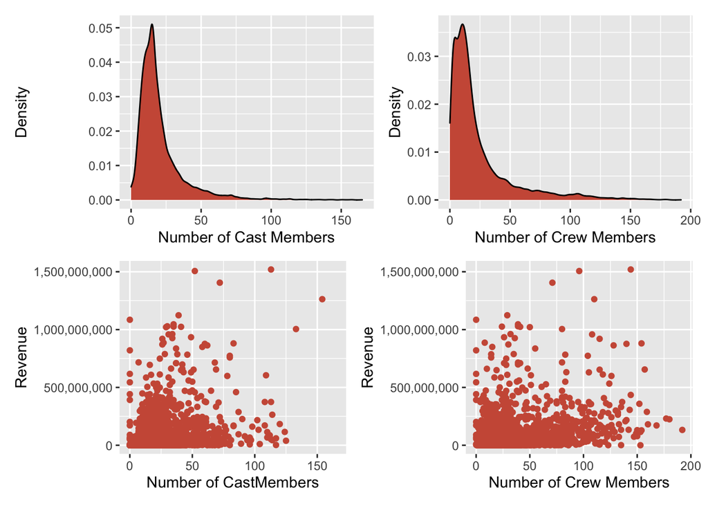

```r
movie_data$cast_count <- str_count(movie_data$cast, "'name':\\s'")
movie_data$crew_count <- str_count(movie_data$crew, "'name':\\s'")

# Impute median for missing crew_count values
movie_data[is.na(movie_data$crew_count),]$crew_count <- median(movie_data$crew_count, na.rm=TRUE)

p8 <- ggplot(movie_data, aes(x = cast_count)) +
  geom_density(fill= "coral3") +
  labs(x = "Number of Cast Members", y = "Density")

p9 <- ggplot(movie_data, aes(x = crew_count)) +
  geom_density(fill = "coral3") +
  labs(x = "Number of Crew Members", y = "Density")


p10 <- ggplot(movie_data, aes(x = cast_count, y = revenue)) +
  geom_point(color = "coral3") +
  scale_y_continuous(labels = comma) +
  labs(x = "Number of CastMembers", y = "Revenue")

p11 <- ggplot(movie_data, aes(x = crew_count, y = revenue)) +
  geom_point(color = "coral3") +
  scale_y_continuous(labels = comma) +
  labs(x = "Number of Crew Members", y = "Revenue")

(p8 + p9)/(p10 + p11)
```

## 2.5 Original Language

Most of the movies have an original language of English, so I created an indicator variable that specifies whether the original language was English. The plot below shows that the log revenue is greater for movies where the original language was English. As a result, I will leave the indicator variable in the dataset and drop the original language variable.

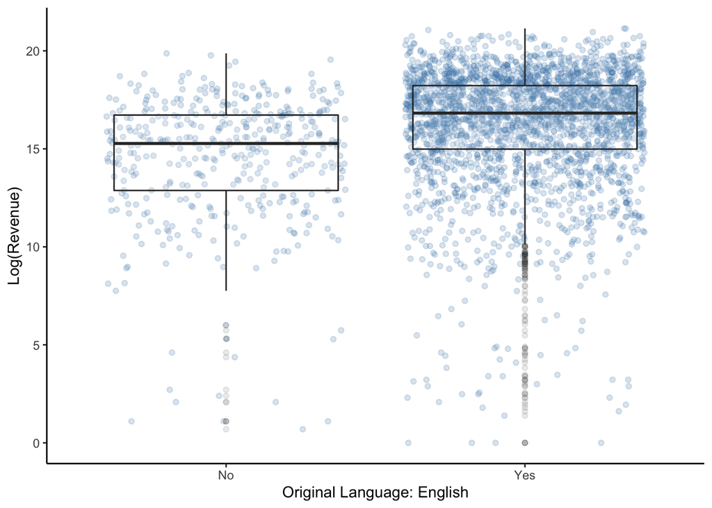

```r
# Most of the movies are English, so I'm going to add another indicator variable to specify if the original language was English or not
movie_data <- movie_data %>% mutate(English = ifelse(original_language == "en", 1, 0))

ggplot(movie_data, aes(x = factor(English), y = log(revenue))) +
  geom_jitter(alpha = .2, color = 'steelblue') +
  geom_boxplot(alpha = .1) +
  scale_x_discrete(labels = c("No", "Yes")) +
  labs(x = 'Original Language: English', y = 'Log(Revenue)') +
  theme_classic()
```

```r
# Drop original langauge column
movie_data <- movie_data %>% select(-original_language)
```

## 2.6 Function to extract useful data

This is a function that was written to used to extract information about the spoken languages, genres, production countries, and production companies and create dummy variables to be used for the model.

```r
extract_n_most_freq_to_dummy <- function(vect, pattern, name, n_most_pattern_fun, n_most_freq=NULL) {

  # Get all vars into a usable list
  var_extractor <- function(x) {
      unlist(str_extract_all(x, pattern=pattern))
  }

  if(!is.null(n_most_freq)) {
    n_most_freq <- n_most_freq
    extracted_vars <- lapply(vect, var_extractor) %>%
      unlist()

    # Find n most frequently appearing vars
    var_freq <- tibble(var = extracted_vars) %>%
      group_by(var) %>%
      count() %>%
      arrange(desc(n)) %>%
      ungroup() %>%
      filter(!is.na(var)) %>%
      top_n(n_most_freq, n)

    # Create new regular expression for most frequently occuring vars
    var_regex <- n_most_pattern_fun(var_freq$var)
    # var_regex <- paste(var_freq$var, collapse="|") %>%
    #   str_replace_all('([^a-zA-Z0-9 |\\-])', '\\\\\\1')

    new_vars <- sapply(vect, function(x) {
      unlist(str_extract_all(x, var_regex))
      })

    dummy_vars <- qdapTools::mtabulate(new_vars)
  }
  else {
    extracted_vars <- sapply(vect, var_extractor)
    dummy_vars <- qdapTools::mtabulate(extracted_vars)
  }

  colnames(dummy_vars) <- paste0(name, gsub("\\W", "", colnames(dummy_vars)))
  rownames(dummy_vars) <- 1:nrow(dummy_vars)

  return(dummy_vars)
}
```

```r
extract_n_most_freq <- function(vect, pattern, name, n_most_pattern_fun, n_level) {

  # Get all vars into a usable list
  var_extractor <- function(x) {
      unlist(str_extract_all(x, pattern=pattern))
  }

  if(!is.null(n_level)) {
    n_level <- n_level
    extracted_vars <- lapply(vect, var_extractor) %>%
      unlist()

    # Find n most frequently appearing vars
    var_freq <- tibble(var = extracted_vars) %>%
      mutate(var = fct_lump(var, n = n_level)) %>%
      group_by(var) %>%
      count() %>%
      arrange(desc(n)) %>%
      ungroup() %>%
      filter(!is.na(var))
  }
  return(var_freq)
}
```

### 2.6.1 Spoken Languages

There are 98 different spoken languages for all of the different movies. I decided to take the top 10 languages and create indicator variables for them and all of the other languages will be grouped together. From the bargraph below, most of the movies have English as a spoken language. The other group is next, which in part is because there are 88 language combined together in that category. Even then, the other gorup isn’t close the number of movies with English as a spoken language. Most movies have one spoken language usually, but ocassionally they have more.

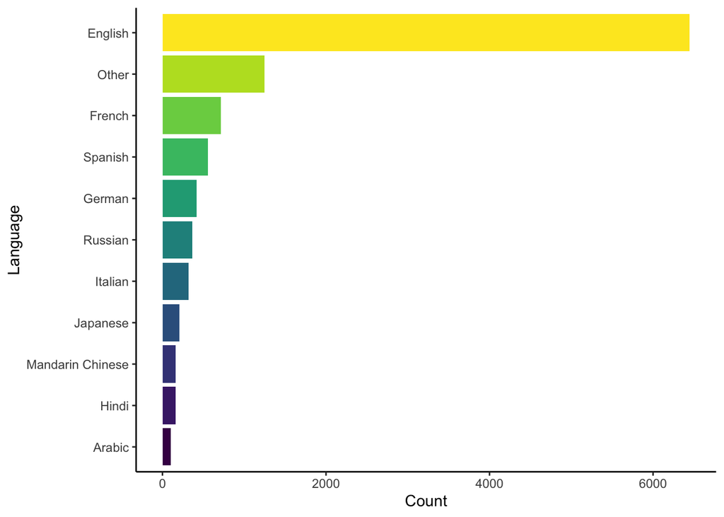

```r
pattern <- "(?<=')[:lower:]{2}(?=')"
pattern_fun <- function(x) {
  paste(x, collapse="|") %>%
    paste0("(?<=')(", ., ")")
}
name <- 'Sp_'
n <- 10

dummy_sp <- extract_n_most_freq_to_dummy(movie_data$spoken_languages, pattern, name, pattern_fun, n)
freq_sp <- extract_n_most_freq(movie_data$spoken_languages, pattern, name, pattern_fun, n)
freq_sp <- freq_sp %>% mutate(var = c("English", "Other", "French", "Spanish", "German", "Russian", "Italian", "Japanese", "Mandarin Chinese", "Hindi", "Arabic"))

p12 <- freq_sp %>%
  mutate(var = fct_reorder(var, n)) %>%
  ggplot(aes(x = factor(var), y = n, fill = var)) +
  geom_bar(stat = "identity") +
  labs(x = "Language", y = "Count") +
  coord_flip() +
  scale_fill_viridis_d() +
  theme_classic() +
  theme(legend.position = "none")

p12
```

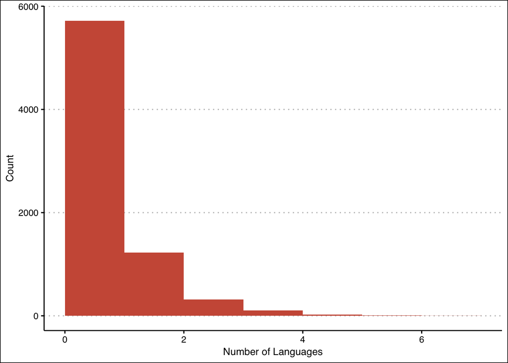

```r
movie_data <- cbind(movie_data, dummy_sp)
# Number of spoken languages
movie_data$Num_Languages <- movie_data %>%
  select(Sp_ar:Sp_zh) %>%
  rowSums()

ggplot(movie_data, aes(x = Num_Languages)) +
  geom_histogram(fill = "coral3", boundary  = 0, binwidth = 1) +
  labs(x = "Number of Languages", y = "Count") +
  theme_clean()
```

### 2.6.2 Genres

One note about the median revenue plot: I assumed that the genre that was listed first was considered the main genre for the movie. I’m not sure if that assumption is correct, but that is the assumption that was made when creatign that plot. The same assumption will apply to the median revenue graphs for production companies and production countries.

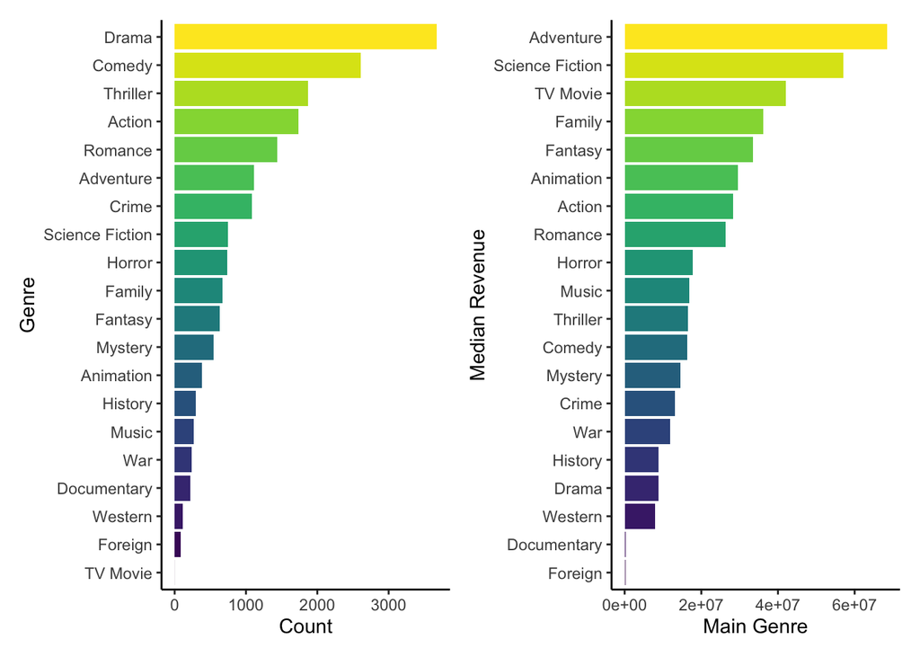

```r
pattern <- "(?<=\')([A-Z])\\w+(.*?)(?=\')"
pattern_fun <- function(x) {
  paste(x, collapse="|")
}
name <- 'Genre'
n <- NULL

dummy_g <- extract_n_most_freq_to_dummy(movie_data$genres, pattern, name, pattern_fun, n)
freq_g <- extract_n_most_freq(movie_data$genres, pattern, name, pattern_fun, 19)
p13 <- freq_g %>%
  mutate(var = fct_reorder(var, n)) %>%
  ggplot(aes(x = factor(var), y = n, fill = var)) +
  geom_bar(stat = "identity") +
  labs(x = "Genre", y = "Count") +
  coord_flip() +
  scale_fill_viridis_d() +
  theme_classic() +
  theme(legend.position = "none")
movie_data <- cbind(movie_data, dummy_g)

p14 <- movie_data %>%
  filter(!is.na(genres)) %>%
  mutate(genre_first = str_extract(genres, "(?<=\')([A-Z])\\w+(.*?)(?=\')")) %>%
  group_by(genre_first) %>%
  summarize(medrev = median(revenue, na.rm = TRUE)) %>%
  mutate(genre_first = fct_reorder(genre_first, medrev)) %>%
  ggplot(aes(x = factor(genre_first), y = medrev, fill = genre_first)) +
  geom_bar(stat = "identity") +
  scale_fill_viridis_d() +
  coord_flip() +
  theme_classic() +
  theme(legend.position = "none") +
  labs(x = "Median Revenue", y = "Main Genre")
p13 + p14
```

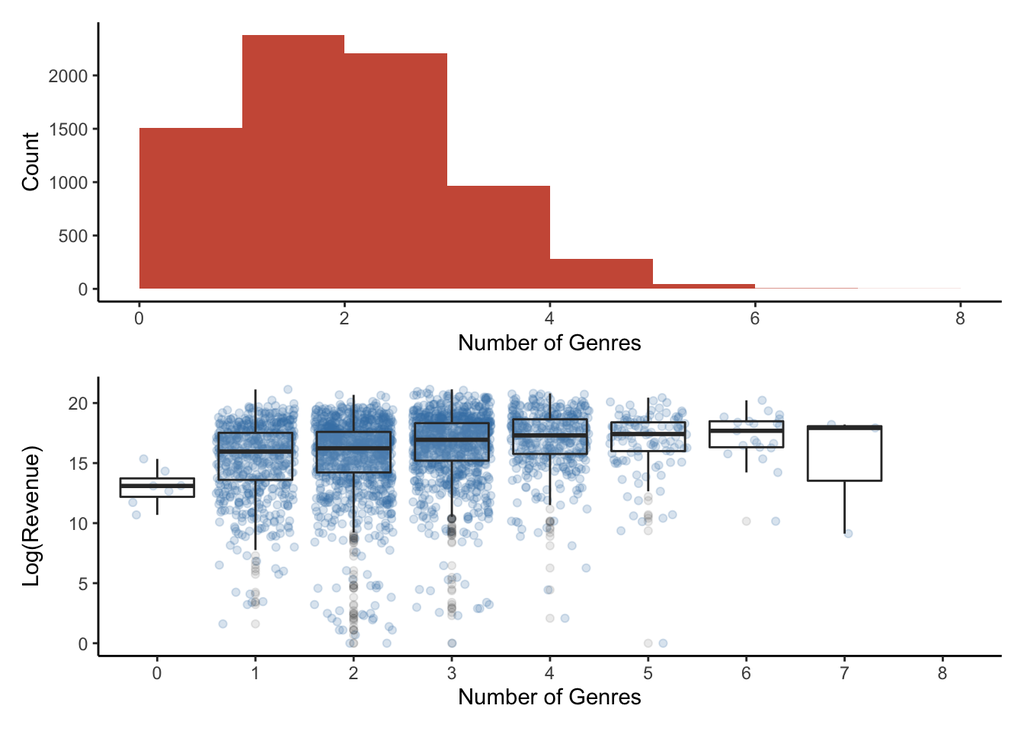

```r
# number of genres
movie_data$num_genres <- movie_data %>% select(GenreAction:GenreWestern) %>% rowSums()

p15 <- ggplot(movie_data, aes(x = num_genres)) +
  geom_histogram(fill = "coral3", boundary  = 0, binwidth = 1) +
  labs(x = "Number of Genres", y = "Count") +
  theme_classic()
p16 <- ggplot(movie_data, aes(x =factor(num_genres), y = log(revenue))) +
  geom_jitter(alpha = .2, color = 'steelblue') +
  geom_boxplot(alpha = .1) +
  labs(x = 'Number of Genres', y = 'Log(Revenue)') +
  theme_classic()
p15 / p16
```

### 2.6.3 Countries

There are 97 different countries where movies were produced. TThe most movies were produced in the United States, which isn’t very surprising. The previous assumption that was mentioned with genres is assumed here as well. The United States has a relatively high median revenue, but Germany has an extremely high. The other countries have a relatively low median revenue, even though there are a lot of movies produced in the 87 other countries that are not listed.

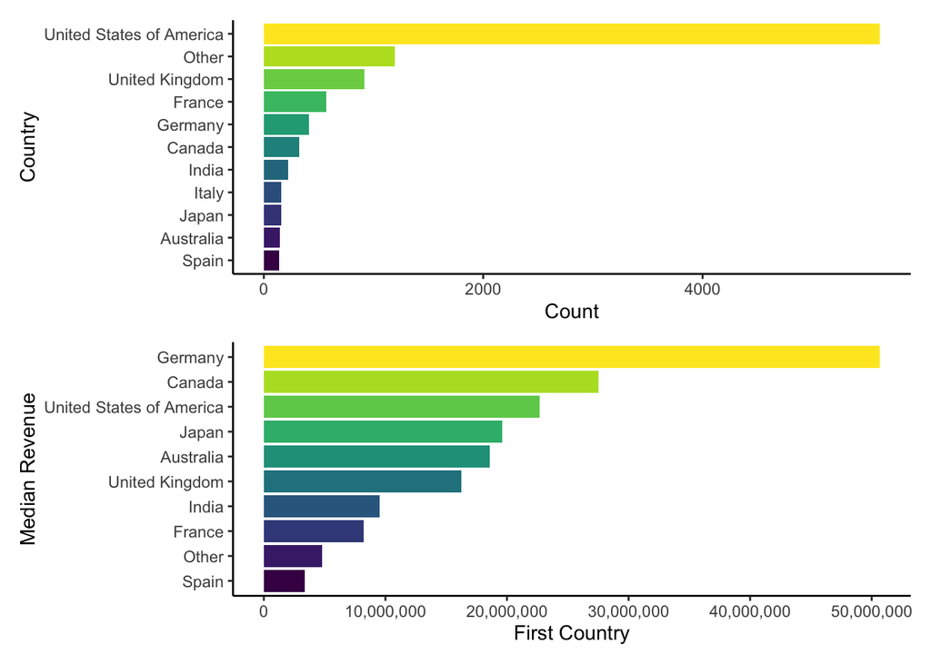

```r
pattern <- "(?<=name': ')[A-Za-z\\s]+"
pattern_fun <- function(x) {
  paste(x, collapse="|")
}
name <- 'Country'
n <- 10

dummy_c <- extract_n_most_freq_to_dummy(movie_data$production_countries, pattern, name, pattern_fun, n)
freq_c <- extract_n_most_freq(movie_data$production_countries, pattern, name, pattern_fun, n)
p17 <- freq_c %>%
  mutate(var = fct_reorder(var, n)) %>%
  ggplot(aes(x = factor(var), y = n, fill = var)) +
  geom_bar(stat = "identity") +
  labs(x = "Country", y = "Count") +
  coord_flip() +
  scale_fill_viridis_d() +
  theme_classic() +
  theme(legend.position = "none")

p18 <- movie_data %>%
  filter(!is.na(production_countries)) %>%
  mutate(country_first = str_extract(production_countries, "(?<=name': ')[A-Za-z\\s]+"),
         country_first = fct_lump(country_first, 10)) %>%
  group_by(country_first) %>%
  summarize(medrev = median(revenue, na.rm = TRUE)) %>%
  filter(country_first %in% freq_c$var) %>%
  mutate(country_first = fct_reorder(country_first, medrev)) %>%
  ggplot(aes(x = factor(country_first), y = medrev, fill = country_first)) +
  geom_bar(stat = "identity") +
  scale_fill_viridis_d() +
  coord_flip() +
  theme_classic() +
  theme(legend.position = "none") +
  labs(x = "Median Revenue", y = "First Country") +
  scale_y_continuous(labels = comma)
p17 / p18
```

```r
movie_data <- cbind(movie_data, dummy_c)
```

### 2.6.4 Production Companies

There are a lot of production companies and as a result, the other category is extremely large. On the plot that shows the number of films made by each production company, the other category was filtered out because it was so much larger than the other ones. Disney easily has the highest median revenue even though they produce fewer films than most of the other top ten production companies. Warner Brothers produces a lot of movies, but has a lower median revenue.

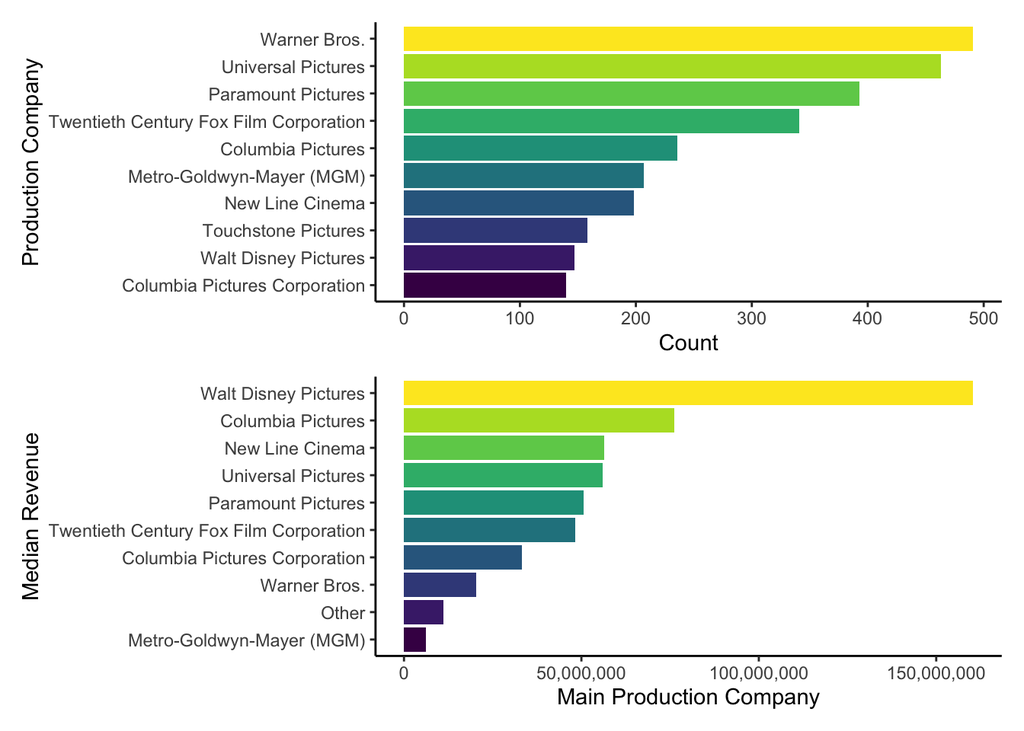

```r
pattern <- "(?<=name': ')[^']+"
pattern_fun <- function(x) {
  paste(x, collapse="|") %>%
      str_replace_all('([^a-zA-Z0-9 |\\-])', '\\\\\\1')
}
name <- 'Comp'
n <- 10

dummy_comp <- extract_n_most_freq_to_dummy(movie_data$production_companies, pattern, name, pattern_fun, n)
freq_pc <- extract_n_most_freq(movie_data$production_companies, pattern, name, pattern_fun, n)

p19 <- freq_pc %>%
  filter(var != "Other") %>%
  mutate(var = fct_reorder(var, n)) %>%
  ggplot(aes(x = factor(var), y = n, fill = var)) +
  geom_bar(stat = "identity") +
  labs(x = "Production Company", y = "Count") +
  coord_flip() +
  scale_fill_viridis_d() +
  theme_classic() +
  theme(legend.position = "none")


p20 <- movie_data %>%
  filter(!is.na(production_companies)) %>%
  mutate(company_first = str_extract(production_companies, "(?<=name': ')[^']+"),
         company_first = fct_lump(company_first, 10)) %>%
  group_by(company_first) %>%
  summarize(medrev = median(revenue, na.rm = TRUE)) %>%
  filter(company_first %in% freq_pc$var) %>%
  mutate(company_first = fct_reorder(company_first, medrev)) %>%
  ggplot(aes(x = factor(company_first), y = medrev, fill = company_first)) +
  geom_bar(stat = "identity") +
  scale_fill_viridis_d() +
  coord_flip() +
  theme_classic() +
  theme(legend.position = "none") +
  labs(x = "Median Revenue", y = "Main Production Company") +
  scale_y_continuous(labels = comma)
p19 /p20
```

```r
movie_data <- cbind(movie_data, dummy_comp)
```

## 2.7 Imputation: Runtime

There were a few movies where the runtime of the movie as missing, so I imputed the median for the runtime for those movies.

```r
# Median imputation for the runtime variable
movie_data[is.na(movie_data$runtime),]$runtime <- median(movie_data[!is.na(movie_data$runtime),]$runtime)
```

## 2.8 Remove original string variables

The variables that I used to create the dummy variables are removed from the dataset.

```r
movie_data_1 <- movie_data %>%
  select(-c(id, genres, production_companies,
            production_countries, spoken_languages,
            title, cast, crew))
```

# 3 Model Fitting

## 3.1 Preprocessing

At this point, I have extracted enough variables that I am prepared to fit some models and see how they perform. There is some preprocessing I wanted to do before I fit the model. Specifically, I split the dataset back into the training and test sets and then I removed near-zero variance variables, and centered and scaled variables. From previous attempts, the performance of the models improved when doing this.

```r
# Split dataset into original train/test split
movie.train.pre <- movie_data_1 %>%
  filter(!is.na(revenue)) %>%
  select(-revenue)
movie.test.pre <- movie_data_1 %>%
  filter(is.na(revenue)) %>%
  select(-revenue)

# Remove variables with near-zero variance and reduce dimensionality
train <- preProcess(movie.train.pre, method = c("nzv", "center", "scale"))
movie.train <- predict(train, movie.train.pre)
movie.test <- predict(train, movie.test.pre)

movie.train <- movie.train %>%
  mutate(revenue = movie_data_1$revenue[!is.na(movie_data_1$revenue)])
```

## 3.2 Summary function and trainControl

I am learning to use the `caret` package in R and all of the models will be fit using the caret package. This competition is measuring RMSLE, which `caret` doesn’t calculate, so this custom summary function was written in order to calculate the RMSLE. Below there are four different models that are fit, which I will include as examples of the different models. The code for them are all very similar with the only difference being the specified method (model) and the tuning parameters that are used to create the grid. If you have questions about this, I suggest looking at the manual for `caret` (http://topepo.github.io/caret/).

```r
# Using rmsle as scoring function for cross validation fitting
custom_summary <- function(data, lev = NULL, model = NULL) {
  out <- Metrics::rmsle(data[, "obs"], data[, "pred"])
  names(out) <- c("rmsle")
  return(out)
}

myControl <- trainControl(method = "cv",
                          number = 3,
                          summaryFunction = custom_summary)
```

## 3.3 Random Forest

```r
grid <- expand.grid("mtry" = c(20, 25, 30), "splitrule" = "extratrees", min.node.size = c(1, 3, 5))

set.seed(1989)
model.rf2 <- train(log(revenue)~.,
                  data = movie.train,
                  method = "ranger",
                  tuneGrid = grid,
                  trControl = myControl,
                  metric = "rmsle",
                  maximize = FALSE); beepr::beep(3)

model.rf2
```

```
## Random Forest
##
## 3000 samples
##   38 predictor
##
## No pre-processing
## Resampling: Cross-Validated (3 fold)
## Summary of sample sizes: 2000, 2000, 2000
## Resampling results across tuning parameters:
##
##   mtry  min.node.size  rmsle
##   20    1              0.2219713
##   20    3              0.2220267
##   20    5              0.2216521
##   25    1              0.2214512
##   25    3              0.2216638
##   25    5              0.2214669
##   30    1              0.2207968
##   30    3              0.2208167
##   30    5              0.2212510
##
## Tuning parameter 'splitrule' was held constant at a value of extratrees
## rmsle was used to select the optimal model using the smallest value.
## The final values used for the model were mtry = 30, splitrule = extratrees
##  and min.node.size = 1.
```

```r
preds.rf2 <- predict(model.rf2, newdata = movie.test) %>% exp()
rf.dat2 <- data.frame(id = movie_test[,1], revenue = preds.rf2)
write_csv(rf.dat2, path = "rf_nopca2.csv")
```

## 3.4 Gradient Boosting Forest

```r
grid <- expand.grid("n.trees"=500, "interaction.depth"=4, "shrinkage"=0.1, "n.minobsinnode"=20)

set.seed(1989)
rfb.mod <- train(log(revenue)~.,
                 data=movie.train,
                 method="gbm",
                 tuneGrid=grid,
                 trControl=myControl,
                 metric = "rmsle",
                 verbose=F); beepr::beep(3)

preds <- predict(rfb.mod, newdata = movie.test) %>% exp()
dat <- data.frame(id = movie_test$id, revenue = preds)
write_csv(dat, "rf-gboost-preds.csv")
```

## 3.5 xgbLinear

```r
tunegrid <- expand.grid(nrounds = 60,
                        lambda = .01,
                        alpha = .01,
                        eta = .2)
set.seed(1989)
xgbLinear.model <- train(log(revenue)~.,
                   data = movie.train,
                   method = "xgbLinear",
                   tuneGrid = tunegrid,
                   trControl = myControl,
                   metric = "rmsle",
                   maximize = FALSE); beepr::beep(3)
xgbLinear.model
```

```
## eXtreme Gradient Boosting
##
## 3000 samples
##   38 predictor
##
## No pre-processing
## Resampling: Cross-Validated (3 fold)
## Summary of sample sizes: 2000, 2000, 2000
## Resampling results:
##
##   rmsle
##   0.2227175
##
## Tuning parameter 'nrounds' was held constant at a value of 60
## Tuning
##  parameter 'alpha' was held constant at a value of 0.01
## Tuning parameter
##  'eta' was held constant at a value of 0.2
```

```r
preds <- predict(xgbLinear.model, newdata = movie.test) %>% exp()
dat <- data.frame(id = movie_test$id, revenue = preds)
write_csv(dat, "xgbLinear-preds.csv")
```

## 3.6 XGB Tree

```r
tunegrid <- expand.grid(eta = .25,
                        max_depth = 3,
                        colsample_bytree = .9,
                        subsample = .8,
                        nrounds = 100,
                        min_child_weight = 1,
                        gamma = .075)
set.seed(1989)
xgbTree.model <- train(log(revenue)~.,
                   data = movie.train,
                   method = "xgbTree",
                   tuneGrid = tunegrid,
                   trControl = myControl,
                   metric = "rmsle",
                   maximize = FALSE
)
xgbTree.model
```

[output not shown]

```r
preds <- predict(xgbTree.model, newdata = movie.test) %>% exp()
dat <- data.frame(id = movie_test$id, revenue = preds)
write_csv(dat, "xgbTree-preds.csv")
```

# 4 Conclusion

The best model up to this point got a RMSLE for 2.062, which is approximately the 58th percentile. There are a few things that can be done to improve this model and which I may eventually work on in the future. First, there may be some meaningful information that could be pulled out of the keywords and tagline variables. They did have quite a few missing values, but there still might have been some useful information that could have been extracted from them, which I didn’t attempt at all. Second, I would like to better account for multiple genres, production countries, and production companies. I was able to select the top ten or twenty of each variable, but that was simply an arbitrary number and I have no idea if the predictions would improve or worse if I increased or decreased that number. Third, I think working with different models and playing with the tuning parameters would also lead to improvement in the predictions as well.